# dwb284_assignment_8

Textbook: Chapter 10*, exercise 5, page 498, parts (a) through (f).

For part (b), calculate SSE and SSA using R code; you may use generic functions like mean() and sum(). For part (f), make sure to use TukeyHSD() instead of the function Aho offers; we’ll be using this specific function in class.

5.(a) There are two equivalent null hypotheses: H0: u1 = u2 = … ua HA: u1 != u2 != …. ua

H0: alpha_1 = alpha_2 = … alpha_a = 0. HA: alpha_1 != alpha_2 != … alpha_a !=0 (b)

```r
library(asbio)
data(life.exp)
n.i <- print(with(life.exp, tapply(lifespan,treatment,length)))
```

```
## N/N85 N/R40 N/R50 R/R50
##    57    60    71    56
```

```r
Ybar.i <- print(with(life.exp, tapply(lifespan,treatment,mean)))
```

```
##    N/N85    N/R40    N/R50    R/R50
## 32.69123 45.11667 42.29718 42.88571
```

```r
Ybar <- print(with(life.exp, mean(lifespan)))
```

```
## [1] 40.88156
```

```r
SSA <- print(sum(n.i * (Ybar.i - Ybar)^2))
```

```
## [1] 5267.03
```

```r
SSE <- print(with(life.exp, sum((lifespan - rep(Ybar.i[c(1,3,4,2)], n.i[c(1,3,4,2)]))^2)))
```

```
## [1] 10802.94
```

```r
a <- length(levels(life.exp$treatment))
a
```

```
## [1] 4
```

```r
n <- length(life.exp$treatment)
n
```

```
## [1] 244
```

```r
SSTo <- SSA + SSE
SSTo
```

```
## [1] 16069.97
```

```r
MSA <- SSA / (a-1)
MSA
```

```
## [1] 1755.677
```

```r
MSE <- SSE / (n-a)
MSE
```

```
## [1] 45.01224
```

```r
F.star <- MSA/MSE
F.star
```

```
## [1] 39.00443
```

```r
p_value <- pf(F.star,a-1,n-a, lower.tail=FALSE)
p_value
```

```
## [1] 1.438905e-20
```

I conclude that there is a real effect present in the data based on the very small omnibus p-value. (d)

```r
anova(aov(lifespan~treatment, data=life.exp))
```

```
## Analysis of Variance Table
##
## Response: lifespan
##            Df Sum Sq Mean Sq F value    Pr(>F)
## treatment   3   5267 1755.68  39.004 < 2.2e-16 ***
## Residuals 240  10803   45.01
## ---
## Signif. codes:  0 '***' 0.001 '**' 0.01 '*' 0.05 '.' 0.1 ' ' 1
```

```r
summary.lm(aov(lifespan~treatment, data=life.exp))
```

```
##
## Call:
## aov(formula = lifespan ~ treatment, data = life.exp)
##
## Residuals:
##      Min       1Q   Median       3Q      Max
## -25.5167  -2.9339   0.6615   5.2364   9.6088
##
## Coefficients:
##                Estimate Std. Error t value Pr(>|t|)
## (Intercept)     32.6912     0.8886  36.788  < 2e-16 ***
## treatmentN/R40  12.4254     1.2409  10.013  < 2e-16 ***
## treatmentN/R50   9.6060     1.1932   8.051 3.82e-14 ***
## treatmentR/R50  10.1945     1.2623   8.076 3.25e-14 ***
## ---
## Signif. codes:  0 '***' 0.001 '**' 0.01 '*' 0.05 '.' 0.1 ' ' 1
##
## Residual standard error: 6.709 on 240 degrees of freedom
## Multiple R-squared:  0.3278, Adjusted R-squared:  0.3194
## F-statistic:    39 on 3 and 240 DF,  p-value: < 2.2e-16
```

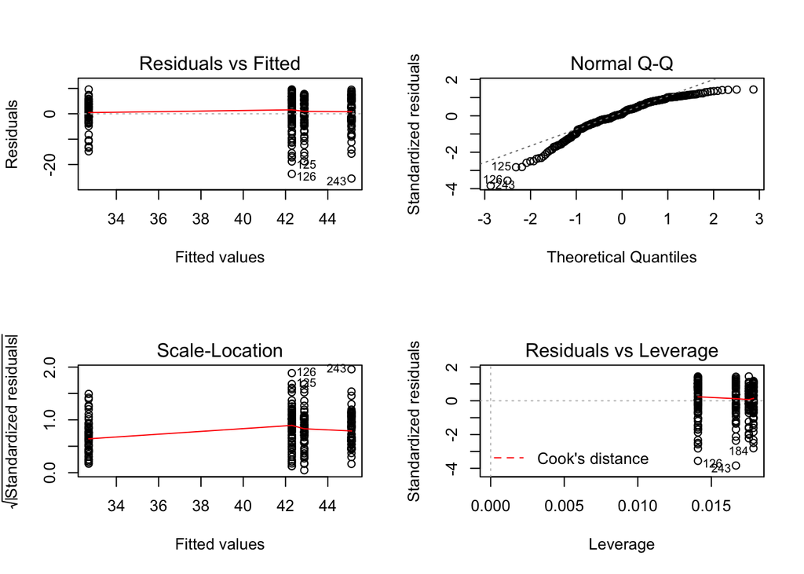

```r
par(mfrow=c(2,2))
aov.treatment<-(aov(lifespan~treatment, data=life.exp))
plot(aov.treatment)
```

The residuals plot looks like a straight line, without appearing to have too many outliers. The normal Q-Q plot also looks relatively correct, with some outliers at both ends. The scale location plot looks okay as well, as it is a mostly straight line. The residuals vs leverage plot looks correct, without too many outliers.

```r
TukeyHSD(aov.treatment)
```

```
##   Tukey multiple comparisons of means
##     95% family-wise confidence level
##
## Fit: aov(formula = lifespan ~ treatment, data = life.exp)
##
## $treatment
##                   diff       lwr        upr     p adj
## N/R40-N/N85 12.4254385  9.215018 15.6358589 0.0000000
## N/R50-N/N85  9.6059554  6.519071 12.6928401 0.0000000
## R/R50-N/N85 10.1944862  6.928685 13.4602879 0.0000000
## N/R50-N/R40 -2.8194831 -5.863260  0.2242942 0.0804712
## R/R50-N/R40 -2.2309523 -5.456039  0.9941344 0.2808243
## R/R50-N/R50  0.5885309 -2.513604  3.6906659 0.9610849
```

The adjusted p values of the Tukey Honest Significant Differences shows that the adjusted p value is very small for the differences between the treatment gropus and the control group. There are no significant adjusted p values for the differences between treatment gropus, which is not unexpected.